# Smoking

# 1 Description of DataSchema variable

The description of harmonised variable is the following:

- Short name: `smoking`
- Variable label: `Composite variable. Any type of tobacco smoking`
- Variable description: `Composite variable. Any type of tobacco smoking`
- Domain: `Lifestyle and health behaviours`
- Value type: `categorical`
- Category coding:

| **Code** | **Category Label** |
| --- | --- |
| 0 | never smoked |
| 1 | ex-smoker |
| 2 | current smoker |

- Category missings:

| **Code** | **Category Label** |
| --- | --- |
| 991 | CAPI/interviewer error |
| 992 | Impute |
| 993 | Disable to measure |
| 994 | Not attempt/not done |
| 995 | Does not answer |
| 996 | Not applicable |
| 997 | Refuse |
| 998 | Do not know |
| 999 | Missing |

# 2 Data process

## 2.1 Cuba

### 2.1.1 Wave 1

#### 2.1.1.1 Study-specific variable description

| **Name** | `smokstat` |
| --- | --- |
| **Label** | `current smoking status (never/ ex/ current smoker)` |
| **Table name** | `1066-Cuba-Baseline` |
| **Categories** | `0 = never smoked` `1 = ex-smoker` `2 = current smoker` |
| **Missings** | `NA` |
| **Description** |  |

smokstat

| Sample size | Missing values |
| --- | --- |
| 2813 | 8 |

Category

|  | 0 | 1 | 2 |
| --- | --- | --- | --- |
| Frequency | 1538.00 | 725.00 | 542.00 |
| Percentage | 54.67 | 25.77 | 19.27 |

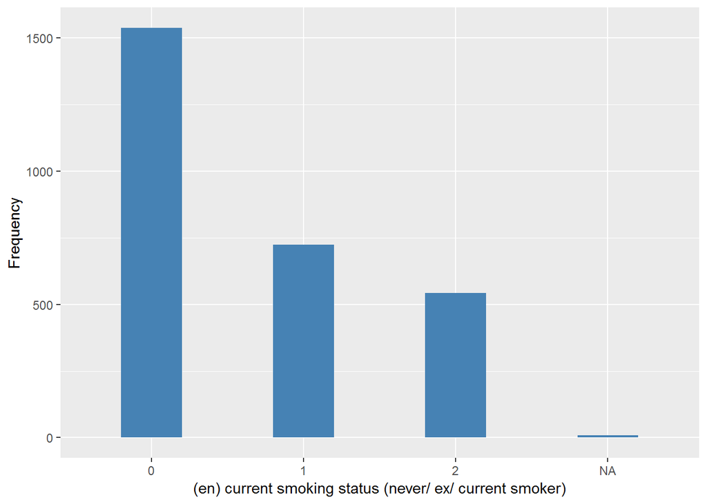

#### 2.1.1.2 Harmonisation algorithm

To compute the harmonize variable from the study-specific variable it has to be recoded as follows:

- `0 into 0`
- `1 into 1`
- `2 into 2`
- `NA into 999`

```r
t1066_ds_cuba_w1 <- tibble(id = t1066_cuba_w1$id)
t1066_ds_cuba_w1$smoking <- Recode(t1066_cuba_w1$smokstat, "0 = '0';1 = '1';2 = '2'; NA = '999'")
t1066_ds_cuba_w1$smoking <- labelled(t1066_ds_cuba_w1$smoking, labels = cat_label)
```

#### 2.1.1.3 Statistical description of the new harmonised variable

Composite variable. Any type of tobacco smoking

| Sample size | Missing values |
| --- | --- |
| 2813 | 8 |

Category

|  | 0 | 1 | 2 |
| --- | --- | --- | --- |
| Frequency | 1538.00 | 725.00 | 542.00 |
| Percentage | 54.67 | 25.77 | 19.27 |

Type of missing

|  | 991 | 992 | 993 | 994 | 995 | 996 | 997 | 998 | 999 | NA |
| --- | --- | --- | --- | --- | --- | --- | --- | --- | --- | --- |
| Frequency | 0 | 0 | 0 | 0 | 0 | 0 | 0 | 0 | 8.00 | 0 |
| Percentage | 0 | 0 | 0 | 0 | 0 | 0 | 0 | 0 | 0.28 | 0 |

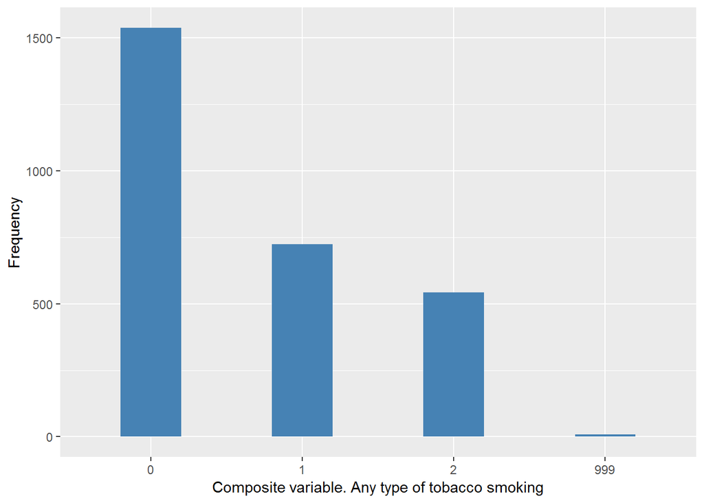

#### 2.1.1.4 Validation

|  | 0->0 | 1->1 | 2->2 | NA->999 |
| --- | --- | --- | --- | --- |
| BeforeH | 1538 | 725 | 542 | 8 |
| AfterH | 1538 | 725 | 542 | 8 |

### 2.1.2 Wave 2

Not found.

## 2.2 India

### 2.2.1 Wave 1

#### 2.2.1.1 Study-specific variable description

| **Name** | `smokstat` |
| --- | --- |
| **Label** | `current smoking status (never/ ex/ current smoker)` |
| **Table name** | `1066-India-Baseline` |
| **Categories** | `0 = never smoked` `1 = ex-smoker` `2 = current smoker` |
| **Missings** | `NA` |
| **Description** |  |

smokstat

| Sample size | Missing values |
| --- | --- |
| 2004 | 8 |

Category

|  | 0 | 1 | 2 |
| --- | --- | --- | --- |
| Frequency | 1199.00 | 128.00 | 669.00 |
| Percentage | 59.83 | 6.39 | 33.38 |

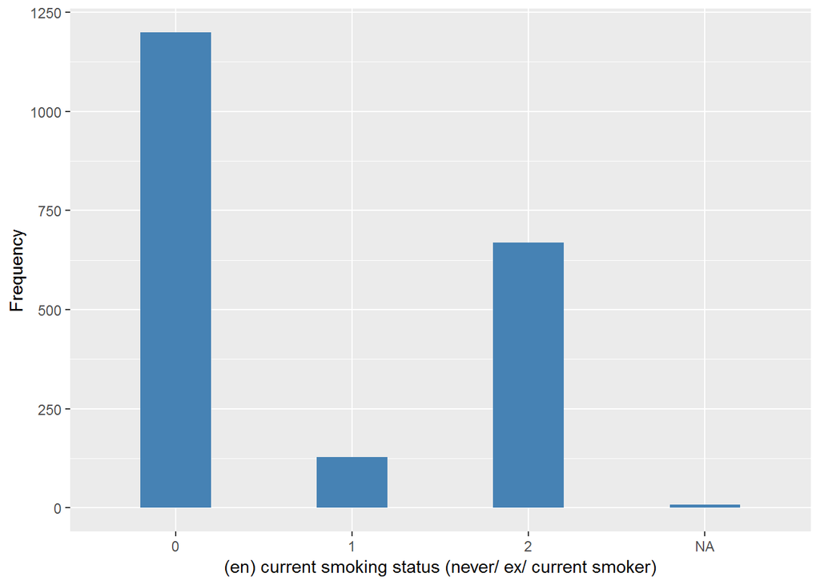

#### 2.2.1.2 Harmonisation algorithm

To compute the harmonize variable from the study-specific variable it has to be recoded as follows:

- `0 into 0`
- `1 into 1`
- `2 into 2`
- `NA into 999`

```r
t1066_ds_india_w1 <- tibble(id = t1066_india_w1$id)
t1066_ds_india_w1$smoking <- Recode(t1066_india_w1$smokstat, "0 = '0';1 = '1';2 = '2'; NA = '999' ")
t1066_ds_india_w1$smoking <- labelled(t1066_ds_india_w1$smoking, labels = cat_label)
```

#### 2.2.1.3 Statistical description of the new harmonised variable

Composite variable. Any type of tobacco smoking

| Sample size | Missing values |
| --- | --- |
| 2004 | 8 |

Category

|  | 0 | 1 | 2 |
| --- | --- | --- | --- |
| Frequency | 1199.00 | 128.00 | 669.00 |
| Percentage | 59.83 | 6.39 | 33.38 |

Type of missing

|  | 991 | 992 | 993 | 994 | 995 | 996 | 997 | 998 | 999 | NA |
| --- | --- | --- | --- | --- | --- | --- | --- | --- | --- | --- |
| Frequency | 0 | 0 | 0 | 0 | 0 | 0 | 0 | 0 | 8.0 | 0 |
| Percentage | 0 | 0 | 0 | 0 | 0 | 0 | 0 | 0 | 0.4 | 0 |

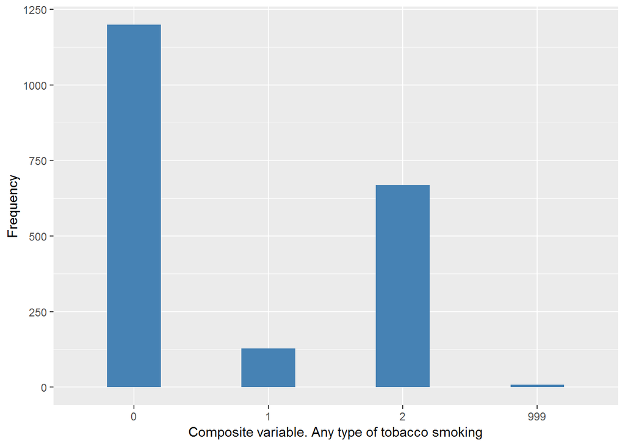

#### 2.2.1.4 Validation

|  | 0->0 | 1->1 | 2->2 | NA->999 |
| --- | --- | --- | --- | --- |
| BeforeH | 1199 | 128 | 669 | 8 |
| AfterH | 1199 | 128 | 669 | 8 |

## 2.3 Urban China

### 2.3.1 Wave 1

#### 2.3.1.1 Study-specific variable description

| **Name** | `smokstat` |
| --- | --- |
| **Label** | `current smoking status (never/ ex/ current smoker)` |
| **Table name** | `1066-UrbanChina-Baseline` |
| **Categories** | `0 = never smoked` `1 = ex-smoker` `2 = current smoker` |
| **Missings** |  |
| **Description** |  |

smokstat

| Sample size | Missing values |
| --- | --- |
| 1160 | 0 |

Category

|  | 0 | 1 | 2 |
| --- | --- | --- | --- |
| Frequency | 875.00 | 92.00 | 193.00 |
| Percentage | 75.43 | 7.93 | 16.64 |

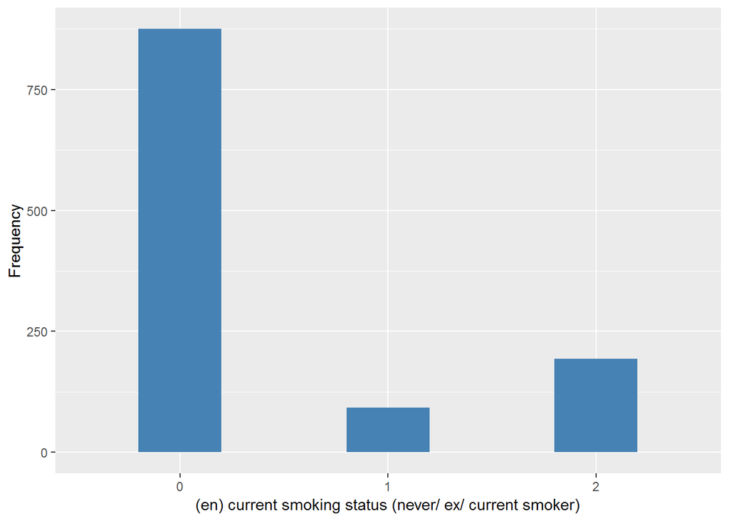

#### 2.3.1.2 Harmonisation algorithm

To compute the harmonize variable from the study-specific variable it has to be recoded as follows:

- `0 into 0`
- `1 into 1`
- `2 into 2`

```r
t1066_ds_UCh_w1 <- tibble(id = t1066_UCh_w1$id)
t1066_ds_UCh_w1$smoking <- Recode(t1066_UCh_w1$smokstat, "0 = '0';1 = '1';2 = '2' ")
t1066_ds_UCh_w1$smoking <- labelled(t1066_ds_UCh_w1$smoking, labels = cat_label)
```

#### 2.3.1.3 Statistical description of the new harmonised variable

Composite variable. Any type of tobacco smoking

| Sample size | Missing values |
| --- | --- |
| 1160 | 0 |

Category

|  | 0 | 1 | 2 |
| --- | --- | --- | --- |
| Frequency | 875.00 | 92.00 | 193.00 |
| Percentage | 75.43 | 7.93 | 16.64 |

Type of missing

|  | 991 | 992 | 993 | 994 | 995 | 996 | 997 | 998 | 999 | NA |
| --- | --- | --- | --- | --- | --- | --- | --- | --- | --- | --- |
| Frequency | 0 | 0 | 0 | 0 | 0 | 0 | 0 | 0 | 0 | 0 |
| Percentage | 0 | 0 | 0 | 0 | 0 | 0 | 0 | 0 | 0 | 0 |

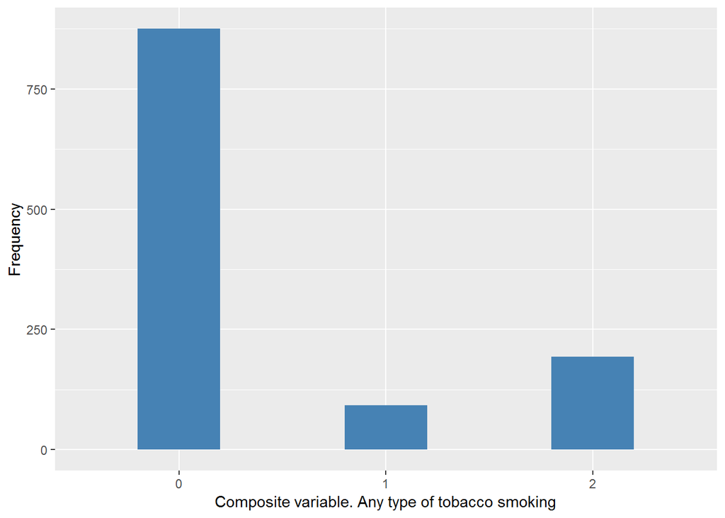

#### 2.3.1.4 Validation

|  | 0->0 | 1->1 | 2->2 |
| --- | --- | --- | --- |
| BeforeH | 875 | 92 | 193 |
| AfterH | 875 | 92 | 193 |

### 2.3.2 Wave 2

Not found.

## 2.4 Rural China

### 2.4.1 Wave 1

#### 2.4.1.1 Study-specific variable description

| **Name** | `smokstat` |
| --- | --- |
| **Label** | `current smoking status (never/ ex/ current smoker)` |
| **Table name** | `1066-RuralChina-Baseline` |
| **Categories** | `0 = never smoked` `1 = ex-smoker` `2 = current smoker` |
| **Missings** |  |
| **Description** |  |

smokstat

| Sample size | Missing values |
| --- | --- |
| 1002 | 0 |

Category

|  | 0 | 1 | 2 |
| --- | --- | --- | --- |
| Frequency | 666.00 | 31.00 | 305.00 |
| Percentage | 66.47 | 3.09 | 30.44 |

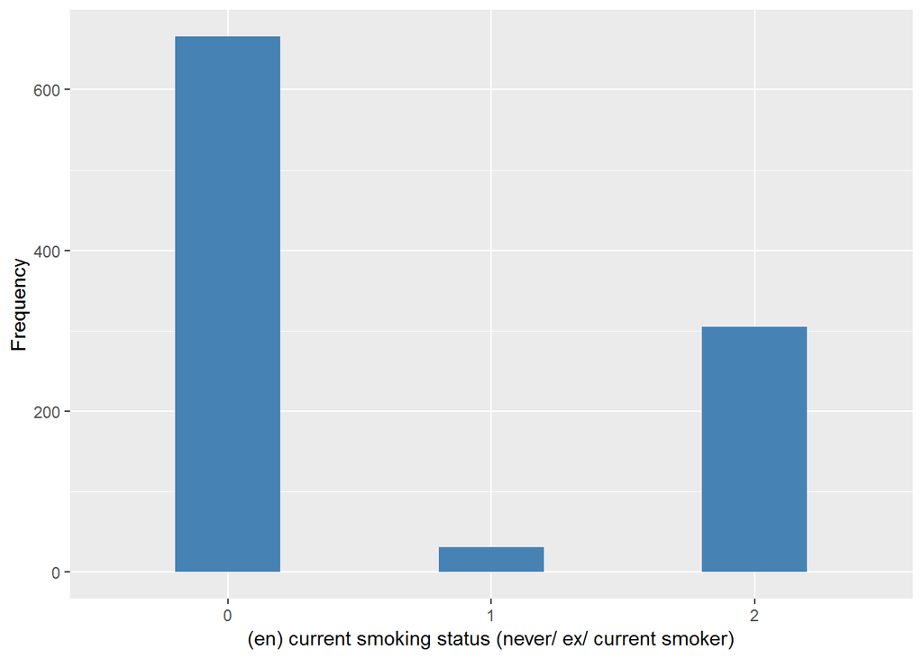

#### 2.4.1.2 Harmonisation algorithm

To compute the harmonize variable from the study-specific variable it has to be recoded as follows:

- `0 into 0`
- `1 into 1`
- `2 into 2`

```r
t1066_ds_RCh_w1 <- tibble(id = t1066_RCh_w1$id)
t1066_ds_RCh_w1$smoking <- Recode(t1066_RCh_w1$smokstat, "0 = '0';1 = '1';2 = '2' ")
t1066_ds_RCh_w1$smoking <- labelled(t1066_ds_RCh_w1$smoking, labels = cat_label)
```

#### 2.4.1.3 Statistical description of the new harmonised variable

Composite variable. Any type of tobacco smoking

| Sample size | Missing values |
| --- | --- |
| 1002 | 0 |

Category

|  | 0 | 1 | 2 |
| --- | --- | --- | --- |
| Frequency | 666.00 | 31.00 | 305.00 |
| Percentage | 66.47 | 3.09 | 30.44 |

Type of missing

|  | 991 | 992 | 993 | 994 | 995 | 996 | 997 | 998 | 999 | NA |
| --- | --- | --- | --- | --- | --- | --- | --- | --- | --- | --- |
| Frequency | 0 | 0 | 0 | 0 | 0 | 0 | 0 | 0 | 0 | 0 |
| Percentage | 0 | 0 | 0 | 0 | 0 | 0 | 0 | 0 | 0 | 0 |

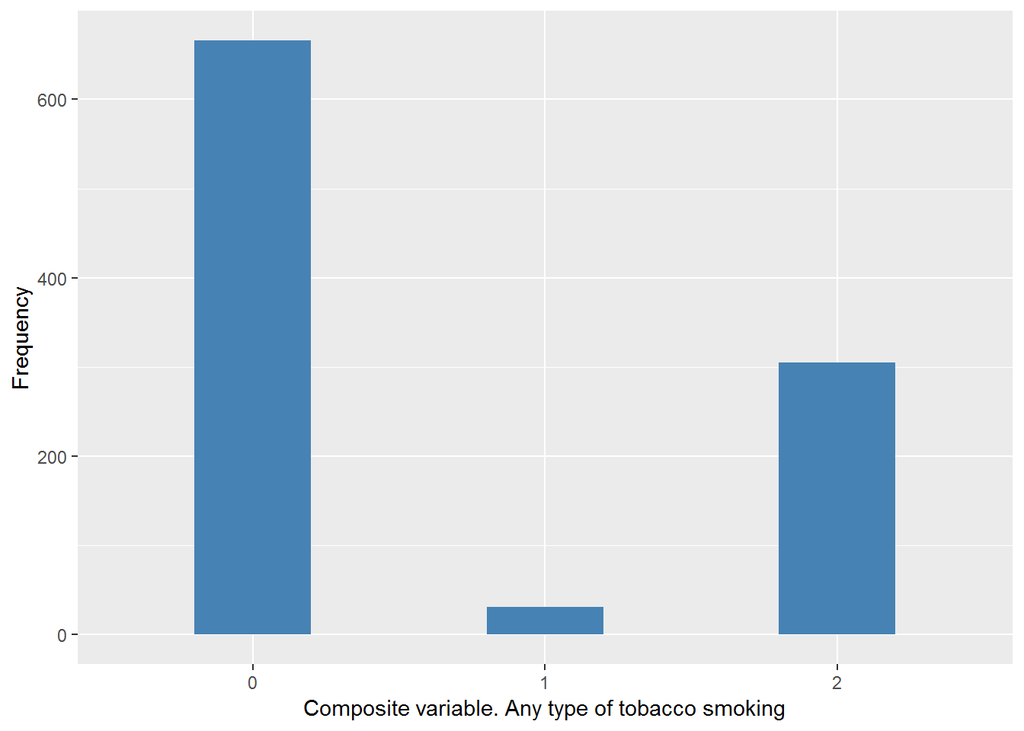

#### 2.4.1.4 Validation

|  | 0->0 | 1->1 | 2->2 |
| --- | --- | --- | --- |
| BeforeH | 666 | 31 | 305 |
| AfterH | 666 | 31 | 305 |

### 2.4.2 Wave 2

Not found.

## 2.5 Dominican Republic

### 2.5.1 Wave 1

#### 2.5.1.1 Study-specific variable description

| **Name** | `smokstat` |
| --- | --- |
| **Label** | `current smoking status (never/ ex/ current smoker)` |
| **Table name** | `1066-DominicanRepublic-Baseline` |
| **Categories** | `0 = never smoked` `1 = ex-smoker` `2 = current smoker` |
| **Missings** | `NA` |
| **Description** |  |

smokstat

| Sample size | Missing values |
| --- | --- |
| 2011 | 2 |

Category

|  | 0 | 1 | 2 |
| --- | --- | --- | --- |
| Frequency | 1049.00 | 711.00 | 249.00 |
| Percentage | 52.16 | 35.36 | 12.38 |

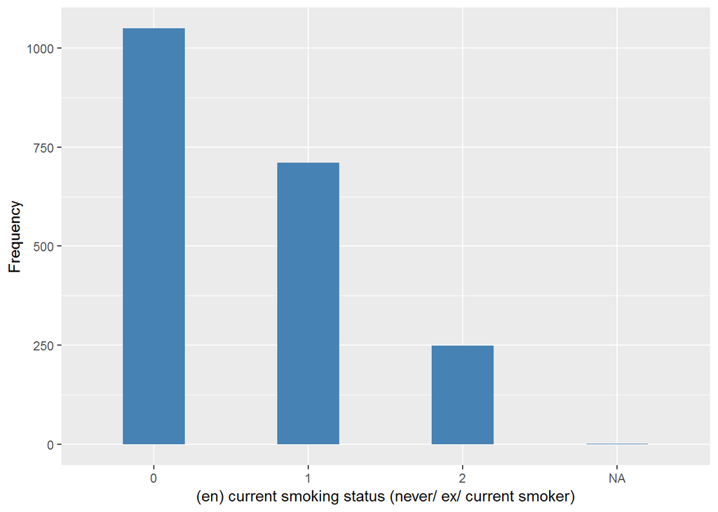

#### 2.5.1.2 Harmonisation algorithm

To compute the harmonize variable from the study-specific variable it has to be recoded as follows:

- `0 into 0`
- `1 into 1`
- `2 into 2`
- `NA into 999`

```r
t1066_ds_DR_w1 <- tibble(id = t1066_DR_w1$id)
t1066_ds_DR_w1$smoking <- Recode(t1066_DR_w1$smokstat, "0 = '0';1 = '1';2 = '2'; NA = '999' ")
t1066_ds_DR_w1$smoking <- labelled(t1066_ds_DR_w1$smoking, labels = cat_label)
```

#### 2.5.1.3 Statistical description of the new harmonised variable

Composite variable. Any type of tobacco smoking

| Sample size | Missing values |
| --- | --- |
| 2011 | 2 |

Category

|  | 0 | 1 | 2 |
| --- | --- | --- | --- |
| Frequency | 1049.00 | 711.00 | 249.00 |
| Percentage | 52.16 | 35.36 | 12.38 |

Type of missing

|  | 991 | 992 | 993 | 994 | 995 | 996 | 997 | 998 | 999 | NA |
| --- | --- | --- | --- | --- | --- | --- | --- | --- | --- | --- |
| Frequency | 0 | 0 | 0 | 0 | 0 | 0 | 0 | 0 | 2.0 | 0 |
| Percentage | 0 | 0 | 0 | 0 | 0 | 0 | 0 | 0 | 0.1 | 0 |

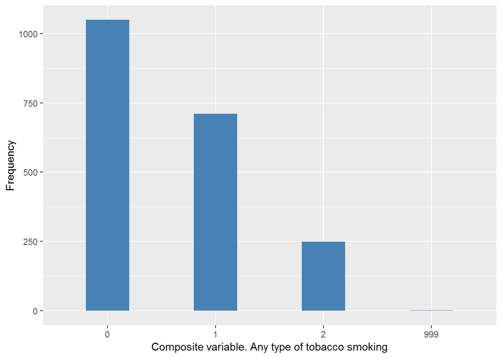

#### 2.5.1.4 Validation

|  | 0->0 | 1->1 | 2->2 | NA->999 |
| --- | --- | --- | --- | --- |
| BeforeH | 1049 | 711 | 249 | 2 |
| AfterH | 1049 | 711 | 249 | 2 |

### 2.5.2 Wave 2

Not found.

## 2.6 Venezuela

### 2.6.1 Wave 1

#### 2.6.1.1 Study-specific variable description

| **Name** | `smokstat` |
| --- | --- |
| **Label** | `current smoking status (never/ ex/ current smoker)` |
| **Table name** | `1066-Venezuela-Baseline` |
| **Categories** | `0 = never smoked` `1 = ex-smoker` `2 = current smoker` |
| **Missings** | `NA` |
| **Description** |  |

smokstat

| Sample size | Missing values |
| --- | --- |
| 1965 | 65 |

Category

|  | 0 | 1 | 2 |
| --- | --- | --- | --- |
| Frequency | 1061.00 | 624.00 | 215.00 |
| Percentage | 53.99 | 31.76 | 10.94 |

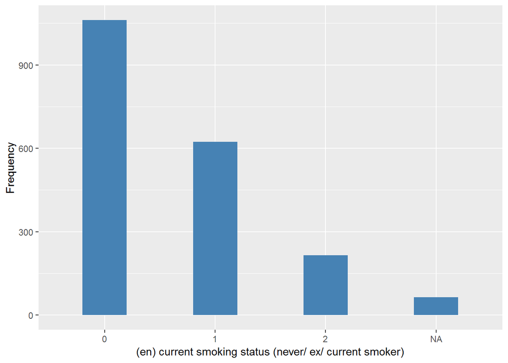

#### 2.6.1.2 Harmonisation algorithm

To compute the harmonize variable from the study-specific variable it has to be recoded as follows:

- `0 into 0`
- `1 into 1`
- `2 into 2`
- `NA into 999`

```r
t1066_ds_Ven_w1 <- tibble(id = t1066_Ven_w1$id)
t1066_ds_Ven_w1$smoking <- Recode(t1066_Ven_w1$smokstat, "0 = '0';1 = '1';2 = '2'; NA = '999' ")
t1066_ds_Ven_w1$smoking <- labelled(t1066_ds_Ven_w1$smoking, labels = cat_label)
```

#### 2.6.1.3 Statistical description of the new harmonised variable

Composite variable. Any type of tobacco smoking

| Sample size | Missing values |
| --- | --- |
| 1965 | 65 |

Category

|  | 0 | 1 | 2 |
| --- | --- | --- | --- |
| Frequency | 1061.00 | 624.00 | 215.00 |
| Percentage | 53.99 | 31.76 | 10.94 |

Type of missing

|  | 991 | 992 | 993 | 994 | 995 | 996 | 997 | 998 | 999 | NA |
| --- | --- | --- | --- | --- | --- | --- | --- | --- | --- | --- |
| Frequency | 0 | 0 | 0 | 0 | 0 | 0 | 0 | 0 | 65.00 | 0 |
| Percentage | 0 | 0 | 0 | 0 | 0 | 0 | 0 | 0 | 3.31 | 0 |

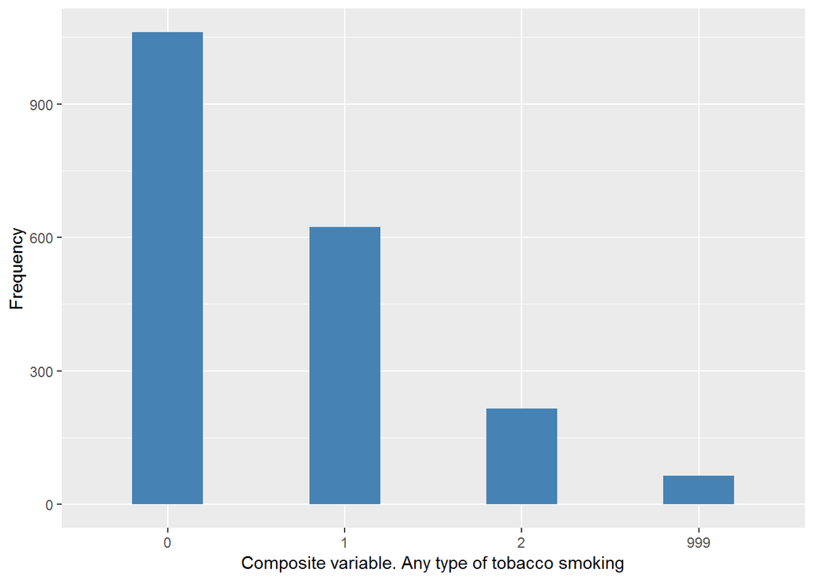

#### 2.6.1.4 Validation

|  | 0->0 | 1->1 | 2->2 | NA->999 |
| --- | --- | --- | --- | --- |
| BeforeH | 1061 | 624 | 215 | 65 |
| AfterH | 1061 | 624 | 215 | 65 |

### 2.6.2 Wave 2

Not found.

## 2.7 Urban Peru

### 2.7.1 Wave 1

#### 2.7.1.1 Study-specific variable description

| **Name** | `smokstat` |
| --- | --- |
| **Label** | `current smoking status (never/ ex/ current smoker)` |
| **Table name** | `1066-UrbanPeru-Baseline` |
| **Categories** | `0 = never smoked` `1 = ex-smoker` `2 = current smoker` |
| **Missings** | `NA` |
| **Description** |  |

smokstat

| Sample size | Missing values |
| --- | --- |
| 1381 | 7 |

Category

|  | 0 | 1 | 2 |
| --- | --- | --- | --- |
| Frequency | 1119.00 | 201.00 | 54.00 |
| Percentage | 81.03 | 14.55 | 3.91 |

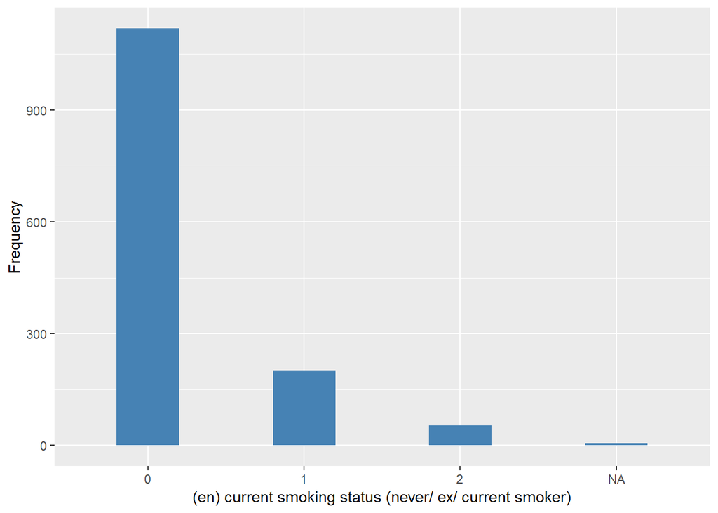

#### 2.7.1.2 Harmonisation algorithm

To compute the harmonize variable from the study-specific variable it has to be recoded as follows:

- `0 into 0`
- `1 into 1`
- `2 into 2`
- `NA into 999`

```r
t1066_ds_UP_w1 <- tibble(id = t1066_UP_w1$id)
t1066_ds_UP_w1$smoking <- Recode(t1066_UP_w1$smokstat, "0 = '0';1 = '1';2 = '2'; NA = '999' ")
t1066_ds_UP_w1$smoking <- labelled(t1066_ds_UP_w1$smoking, labels = cat_label)
```

#### 2.7.1.3 Statistical description of the new harmonised variable

Composite variable. Any type of tobacco smoking

| Sample size | Missing values |
| --- | --- |
| 1381 | 7 |

Category

|  | 0 | 1 | 2 |
| --- | --- | --- | --- |
| Frequency | 1119.00 | 201.00 | 54.00 |
| Percentage | 81.03 | 14.55 | 3.91 |

Type of missing

|  | 991 | 992 | 993 | 994 | 995 | 996 | 997 | 998 | 999 | NA |
| --- | --- | --- | --- | --- | --- | --- | --- | --- | --- | --- |
| Frequency | 0 | 0 | 0 | 0 | 0 | 0 | 0 | 0 | 7.00 | 0 |
| Percentage | 0 | 0 | 0 | 0 | 0 | 0 | 0 | 0 | 0.51 | 0 |

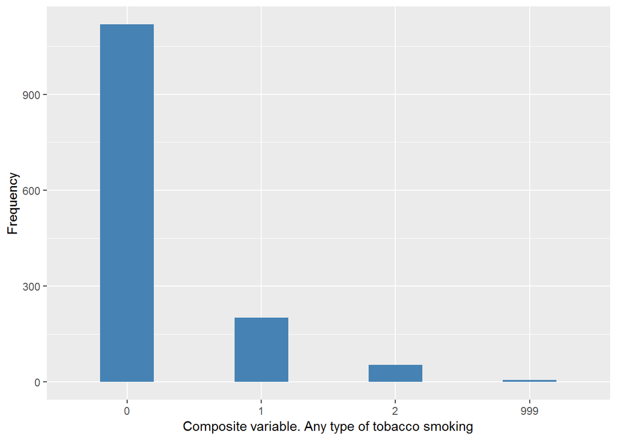

#### 2.7.1.4 Validation

|  | 0->0 | 1->1 | 2->2 | NA->999 |
| --- | --- | --- | --- | --- |
| BeforeH | 1119 | 201 | 54 | 7 |
| AfterH | 1119 | 201 | 54 | 7 |

### 2.7.2 Wave 2

Not found.

## 2.8 Rural Peru

### 2.8.1 Wave 1

#### 2.8.1.1 Study-specific variable description

| **Name** | `smokstat` |
| --- | --- |
| **Label** | `current smoking status (never/ ex/ current smoker)` |
| **Table name** | `1066-RuralPeru-Baseline` |
| **Categories** | `0 = never smoked` `1 = ex-smoker` `2 = current smoker` |
| **Missings** | `NA` |
| **Description** |  |

smokstat

| Sample size | Missing values |
| --- | --- |
| 552 | 1 |

Category

|  | 0 | 1 | 2 |
| --- | --- | --- | --- |
| Frequency | 482.00 | 55.00 | 14.00 |
| Percentage | 87.32 | 9.96 | 2.54 |

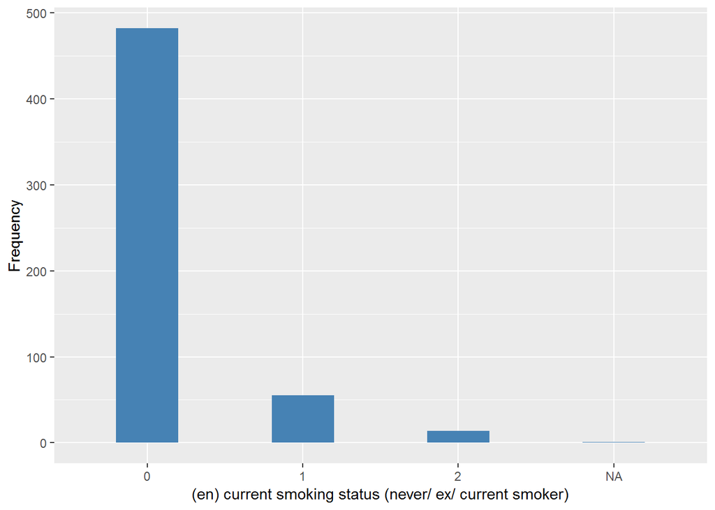

#### 2.8.1.2 Harmonisation algorithm

To compute the harmonize variable from the study-specific variable it has to be recoded as follows:

- `0 into 0`
- `1 into 1`
- `2 into 2`
- `NA into 999`

```r
t1066_ds_RP_w1 <- tibble(id = t1066_RP_w1$id)
t1066_ds_RP_w1$smoking <- Recode(t1066_RP_w1$smokstat, "0 = '0';1 = '1';2 = '2'; NA = '999' ")
t1066_ds_RP_w1$smoking <- labelled(t1066_ds_RP_w1$smoking, labels = cat_label)
```

#### 2.8.1.3 Statistical description of the new harmonised variable

Composite variable. Any type of tobacco smoking

| Sample size | Missing values |
| --- | --- |
| 552 | 1 |

Category

|  | 0 | 1 | 2 |
| --- | --- | --- | --- |
| Frequency | 482.00 | 55.00 | 14.00 |
| Percentage | 87.32 | 9.96 | 2.54 |

Type of missing

|  | 991 | 992 | 993 | 994 | 995 | 996 | 997 | 998 | 999 | NA |
| --- | --- | --- | --- | --- | --- | --- | --- | --- | --- | --- |
| Frequency | 0 | 0 | 0 | 0 | 0 | 0 | 0 | 0 | 1.00 | 0 |
| Percentage | 0 | 0 | 0 | 0 | 0 | 0 | 0 | 0 | 0.18 | 0 |

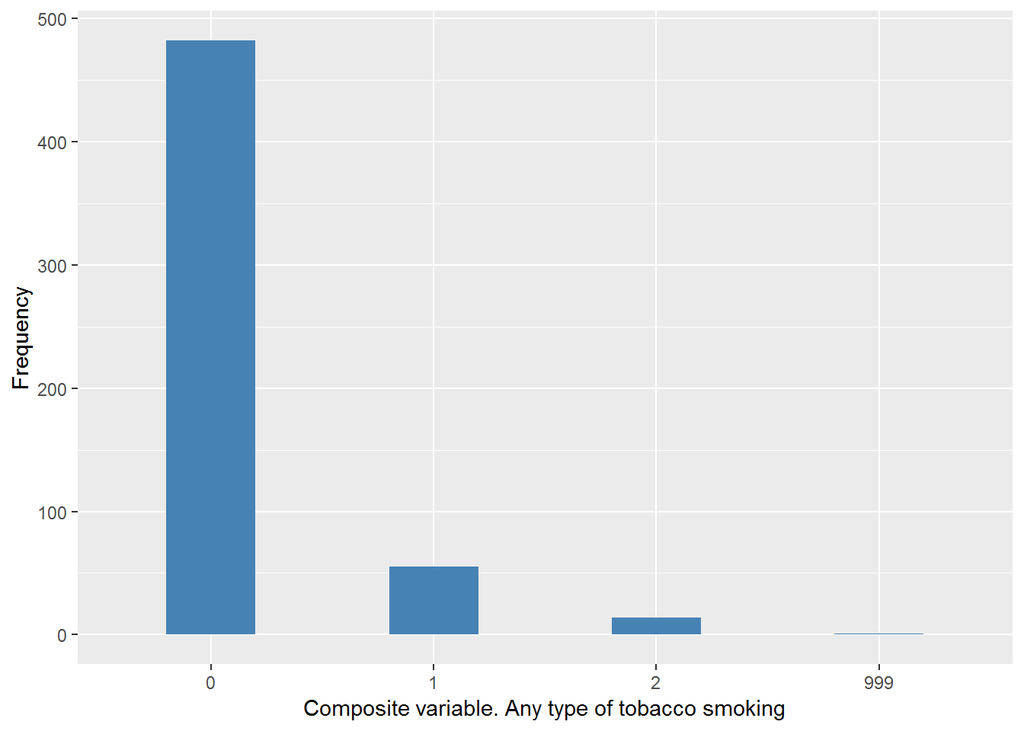

#### 2.8.1.4 Validation

|  | 0->0 | 1->1 | 2->2 | NA->999 |
| --- | --- | --- | --- | --- |
| BeforeH | 482 | 55 | 14 | 1 |
| AfterH | 482 | 55 | 14 | 1 |

### 2.8.2 Wave 2

Not found.

## 2.9 Urban Mexico

### 2.9.1 Wave 1

#### 2.9.1.1 Study-specific variable description

| **Name** | `smokstat` |
| --- | --- |
| **Label** | `current smoking status (never/ ex/ current smoker)` |
| **Table name** | `1066-UrbanMexico-Baseline` |
| **Categories** | `0 = never smoked` `1 = ex-smoker` `2 = current smoker` |
| **Missings** |  |
| **Description** |  |

smokstat

| Sample size | Missing values |
| --- | --- |
| 1003 | 0 |

Category

|  | 0 | 1 | 2 |
| --- | --- | --- | --- |
| Frequency | 648.00 | 246.00 | 109.00 |
| Percentage | 64.61 | 24.53 | 10.87 |

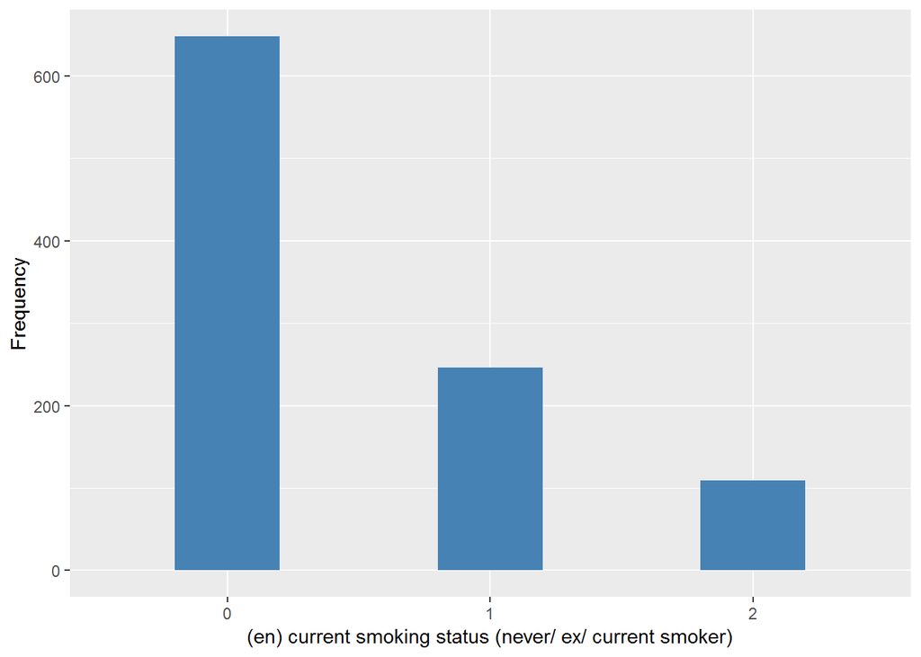

#### 2.9.1.2 Harmonisation algorithm

To compute the harmonize variable from the study-specific variable it has to be recoded as follows:

- `0 into 0`
- `1 into 1`
- `2 into 2`

```r
t1066_ds_UM_w1 <- tibble(id = t1066_UM_w1$id)
t1066_ds_UM_w1$smoking <- Recode(t1066_UM_w1$smokstat, "0 = '0';1 = '1';2 = '2' ")
t1066_ds_UM_w1$smoking <- labelled(t1066_ds_UM_w1$smoking, labels = cat_label)
```

#### 2.9.1.3 Statistical description of the new harmonised variable

Composite variable. Any type of tobacco smoking

| Sample size | Missing values |
| --- | --- |
| 1003 | 0 |

Category

|  | 0 | 1 | 2 |
| --- | --- | --- | --- |
| Frequency | 648.00 | 246.00 | 109.00 |
| Percentage | 64.61 | 24.53 | 10.87 |

Type of missing

|  | 991 | 992 | 993 | 994 | 995 | 996 | 997 | 998 | 999 | NA |
| --- | --- | --- | --- | --- | --- | --- | --- | --- | --- | --- |
| Frequency | 0 | 0 | 0 | 0 | 0 | 0 | 0 | 0 | 0 | 0 |
| Percentage | 0 | 0 | 0 | 0 | 0 | 0 | 0 | 0 | 0 | 0 |

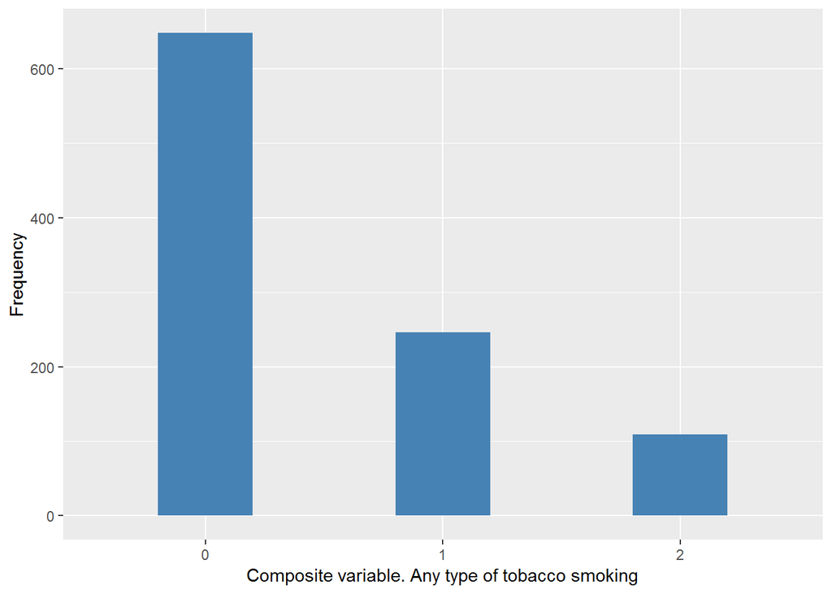

#### 2.9.1.4 Validation

|  | 0->0 | 1->1 | 2->2 |
| --- | --- | --- | --- |
| BeforeH | 648 | 246 | 109 |
| AfterH | 648 | 246 | 109 |

### 2.9.2 Wave 2

Not found.

## 2.10 Rural Mexico

### 2.10.1 Wave 1

#### 2.10.1.1 Study-specific variable description

| **Name** | `smokstat` |
| --- | --- |
| **Label** | `current smoking status (never/ ex/ current smoker)` |
| **Table name** | `1066-RuralMexico-Baseline` |
| **Categories** | `0 = never smoked` `1 = ex-smoker` `2 = current smoker` |
| **Missings** |  |
| **Description** |  |

smokstat

| Sample size | Missing values |
| --- | --- |
| 1000 | 0 |

Category

|  | 0 | 1 | 2 |
| --- | --- | --- | --- |
| Frequency | 729.0 | 200 | 71.0 |
| Percentage | 72.9 | 20 | 7.1 |

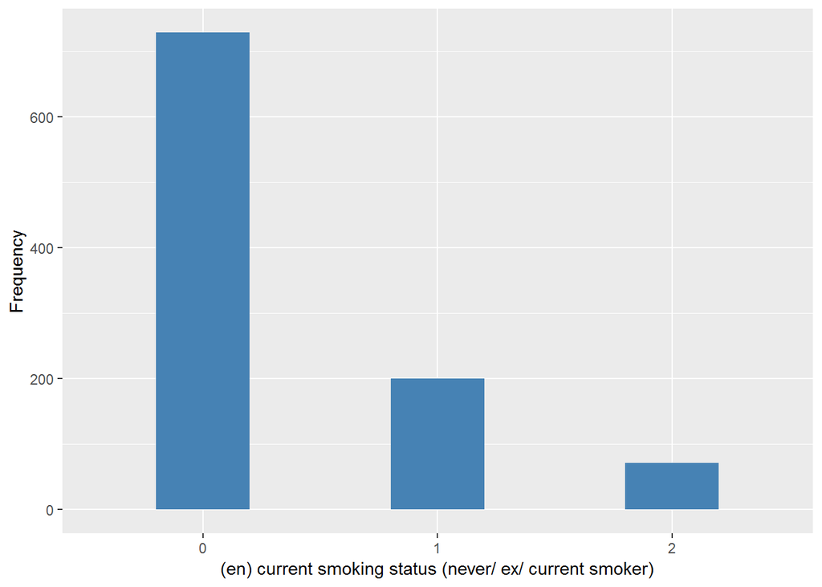

#### 2.10.1.2 Harmonisation algorithm

To compute the harmonize variable from the study-specific variable it has to be recoded as follows:

- `0 into 0`
- `1 into 1`
- `2 into 2`

```r
t1066_ds_RM_w1 <- tibble(id = t1066_RM_w1$id)
t1066_ds_RM_w1$smoking <- Recode(t1066_RM_w1$smokstat, "0 = '0';1 = '1';2 = '2' ")
t1066_ds_RM_w1$smoking <- labelled(t1066_ds_RM_w1$smoking, labels = cat_label)
```

#### 2.10.1.3 Statistical description of the new harmonised variable

Composite variable. Any type of tobacco smoking

| Sample size | Missing values |
| --- | --- |
| 1000 | 0 |

Category

|  | 0 | 1 | 2 |
| --- | --- | --- | --- |
| Frequency | 729.0 | 200 | 71.0 |
| Percentage | 72.9 | 20 | 7.1 |

Type of missing

|  | 991 | 992 | 993 | 994 | 995 | 996 | 997 | 998 | 999 | NA |
| --- | --- | --- | --- | --- | --- | --- | --- | --- | --- | --- |
| Frequency | 0 | 0 | 0 | 0 | 0 | 0 | 0 | 0 | 0 | 0 |
| Percentage | 0 | 0 | 0 | 0 | 0 | 0 | 0 | 0 | 0 | 0 |

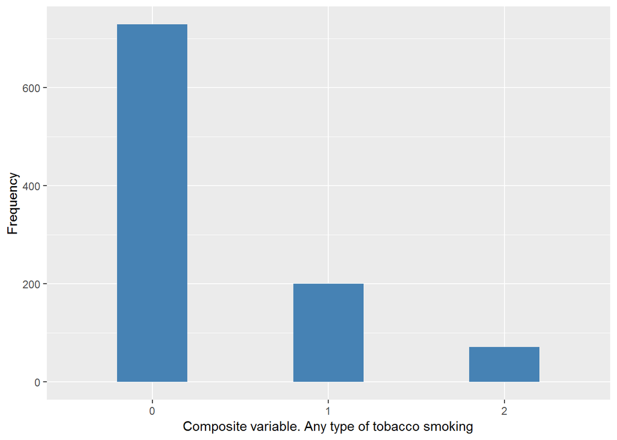

#### 2.10.1.4 Validation

|  | 0->0 | 1->1 | 2->2 |
| --- | --- | --- | --- |
| BeforeH | 729 | 200 | 71 |
| AfterH | 729 | 200 | 71 |

### 2.10.2 Wave 2

Not found.

## 2.11 Puerto Rico

### 2.11.1 Wave 1

#### 2.11.1.1 Study-specific variable description

| **Name** | `smokstat` |
| --- | --- |
| **Label** | `current smoking status (never/ ex/ current smoker)` |
| **Table name** | `1066-PuertoRico-Baseline` |
| **Categories** | `0 = never smoked` `1 = ex-smoker` `2 = current smoker` |
| **Missings** | `NA` |
| **Description** |  |

smokstat

| Sample size | Missing values |
| --- | --- |
| 2009 | 7 |

Category

|  | 0 | 1 | 2 |
| --- | --- | --- | --- |
| Frequency | 1454.00 | 444.0 | 104.00 |
| Percentage | 72.37 | 22.1 | 5.18 |

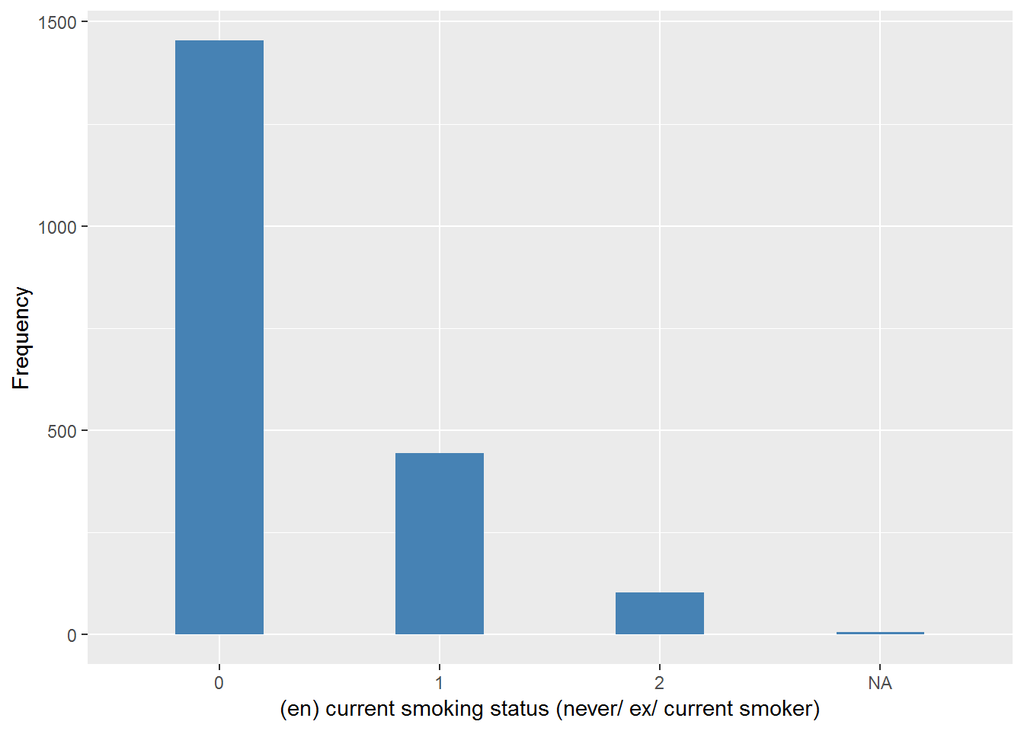

#### 2.11.1.2 Harmonisation algorithm

To compute the harmonize variable from the study-specific variable it has to be recoded as follows:

- `0 into 0`
- `1 into 1`
- `2 into 2`
- `NA into 999`

```r
t1066_ds_PR_w1 <- tibble(id = t1066_PR_w1$id)
t1066_ds_PR_w1$smoking <- Recode(t1066_PR_w1$smokstat, "0 = '0';1 = '1';2 = '2'; NA = '999' ")
t1066_ds_PR_w1$smoking <- labelled(t1066_ds_PR_w1$smoking, labels = cat_label)
```

#### 2.11.1.3 Statistical description of the new harmonised variable

Composite variable. Any type of tobacco smoking

| Sample size | Missing values |
| --- | --- |
| 2009 | 7 |

Category

|  | 0 | 1 | 2 |
| --- | --- | --- | --- |
| Frequency | 1454.00 | 444.0 | 104.00 |
| Percentage | 72.37 | 22.1 | 5.18 |

Type of missing

|  | 991 | 992 | 993 | 994 | 995 | 996 | 997 | 998 | 999 | NA |
| --- | --- | --- | --- | --- | --- | --- | --- | --- | --- | --- |
| Frequency | 0 | 0 | 0 | 0 | 0 | 0 | 0 | 0 | 7.00 | 0 |
| Percentage | 0 | 0 | 0 | 0 | 0 | 0 | 0 | 0 | 0.35 | 0 |

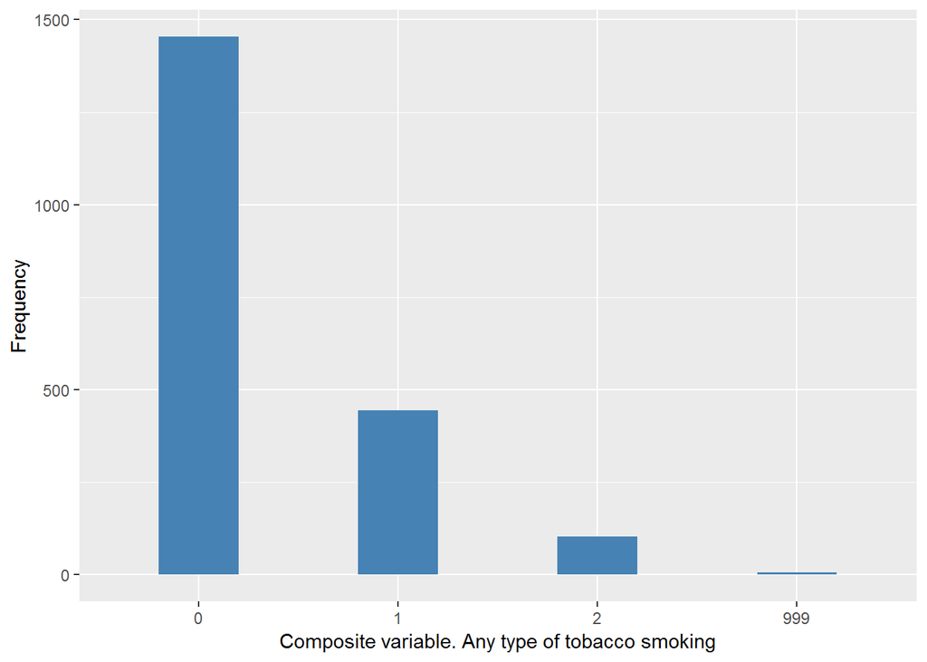

#### 2.11.1.4 Validation

|  | 0->0 | 1->1 | 2->2 | NA->999 |
| --- | --- | --- | --- | --- |
| BeforeH | 1454 | 444 | 104 | 7 |
| AfterH | 1454 | 444 | 104 | 7 |

### 2.11.2 Wave 2

Not found.

## 2.12 Descriptive statistics of the harmonised variable accross populations and waves

Percentages of categories in each harmonised variable:

```r
lb.hds <- list(cuba_w1 = t1066_ds_cuba_w1, india_w1 = t1066_ds_india_w1, UCh_w1 = t1066_ds_UCh_w1,
    RCh_w1 = t1066_ds_RCh_w1, DR_w1 = t1066_ds_DR_w1, Ven_w1 = t1066_ds_Ven_w1,
    UP_w1 = t1066_ds_UP_w1, RP_w1 = t1066_ds_RP_w1, UM_w1 = t1066_ds_UM_w1,
    RM_w1 = t1066_ds_RM_w1, PR_w1 = t1066_ds_PR_w1)

# lf.hds <- list(cuba_w2 = t1066_ds_cuba_w2, UCh_w2 = t1066_ds_UCh_w2,
# RCh_w2 = t1066_ds_RCh_w2, DR_w2 = t1066_ds_DR_w2, Ven_w2 =
# t1066_ds_Ven_w2, UP_w2 = t1066_ds_UP_w2, RP_w2 = t1066_ds_RP_w2, UM_w2 =
# t1066_ds_UM_w2, RM_w2 = t1066_ds_RM_w2, PR_w2 = t1066_ds_PR_w2)

# l.hds <- list(cuba_w1 = t1066_ds_cuba_w1, cuba_w2 = t1066_ds_cuba_w2,
# india_w1 = t1066_ds_india_w1, india_w2 = t1066_ds_india_w2, UCh_w1 =
# t1066_ds_UCh_w1, UCh_w2 = t1066_ds_UCh_w2, RCh_w1 = t1066_ds_RCh_w1,
# RCh_w2 = t1066_ds_RCh_w2, DR_w1 = t1066_ds_DR_w1, DR_w2 = t1066_ds_DR_w2,
# Ven_w1 = t1066_ds_Ven_w1, Ven_w2 = t1066_ds_Ven_w2, UP_w1 =
# t1066_ds_UP_w1, UP_w2 = t1066_ds_UP_w2, RP_w1 = t1066_ds_RP_w1, RP_w2 =
# t1066_ds_RP_w2, UM_w1 = t1066_ds_UM_w1, UM_w2 = t1066_ds_UM_w2, RM_w1 =
# t1066_ds_RM_w1, RM_w2 = t1066_ds_RM_w2, PR_w1 = t1066_ds_PR_w1, PR_w2 =
# t1066_ds_PR_w2)

for (name in names(lb.hds)) {
    aux_object <- lb.hds[[name]]
    label(lb.hds[[name]][[2]]) <- label(aux_object[[2]]) <- ds_label  # Text value assigned at the DS description, at the top
    lb.hds[[name]][[2]] <- labelled(lb.hds[[name]][[2]], labels = cat_label)
    aux_object[[2]] <- car::recode(aux_object[[2]], "miss_values_vector=NA")
    aux_object[[2]] <- labelled(aux_object[[2]], labels = cat_label[1:3])
    m_name <- paste0("t1066_m_ds_", name)
    assign(m_name, aux_object)
    rm(aux_object)
}
# for(name in names(lf.hds)) { aux_object <- lf.hds[[name]]
# label(lf.hds[[name]][[2]]) <- label(aux_object[[2]]) <- ds_label # Text
# value assigned at the DS description, at the top lf.hds[[name]][[2]] <-
# labelled(lf.hds[[name]][[2]], labels = cat_label) aux_object[[2]] <-
# car::recode(aux_object[[2]], 'miss_values_vector=NA') aux_object[[2]] <-
# labelled(aux_object[[2]], labels = cat_label[1:2]) m_name <-
# paste0('t1066_m_ds_',name) assign(m_name, aux_object) rm(aux_object) }

tb.hds <- frq(lb.hds[[1]][2])[[1]][, c(1, 2)]
for (i in seq_along(lb.hds)) {
    tb.hds[2 + i] <- frq(lb.hds[[i]][2])[[1]][, 4]
}
tb.hds[14, ] <- c("n", "sample size", length(lb.hds[[1]][[2]]), length(lb.hds[[2]][[2]]),
    length(lb.hds[[3]][[2]]), length(lb.hds[[4]][[2]]), length(lb.hds[[5]][[2]]),
    length(lb.hds[[6]][[2]]), length(lb.hds[[7]][[2]]), length(lb.hds[[8]][[2]]),
    length(lb.hds[[9]][[2]]), length(lb.hds[[10]][[2]]), length(lb.hds[[11]][[2]]))
names(tb.hds) <- c("val", "label", "cuba_w1", "india_w1", "UCh_w1", "RCh_w1",
    "DR_w1", "Ven_w1", "UP_w1", "RP_w1", "UM_w1", "RM_w1", "PR_w1")
kable(tb.hds)
```

| val | label | cuba_w1 | india_w1 | UCh_w1 | RCh_w1 | DR_w1 | Ven_w1 | UP_w1 | RP_w1 | UM_w1 | RM_w1 | PR_w1 |
| --- | --- | --- | --- | --- | --- | --- | --- | --- | --- | --- | --- | --- |
| 0 | never | 54.67 | 59.83 | 75.43 | 66.47 | 52.16 | 53.99 | 81.03 | 87.32 | 64.61 | 72.9 | 72.37 |
| 1 | past | 25.77 | 6.39 | 7.93 | 3.09 | 35.36 | 31.76 | 14.55 | 9.96 | 24.53 | 20 | 22.1 |
| 2 | current | 19.27 | 33.38 | 16.64 | 30.44 | 12.38 | 10.94 | 3.91 | 2.54 | 10.87 | 7.1 | 5.18 |
| 991 | CAPI interviewer error | 0 | 0 | 0 | 0 | 0 | 0 | 0 | 0 | 0 | 0 | 0 |
| 992 | Impute | 0 | 0 | 0 | 0 | 0 | 0 | 0 | 0 | 0 | 0 | 0 |
| 993 | Disable to measure | 0 | 0 | 0 | 0 | 0 | 0 | 0 | 0 | 0 | 0 | 0 |
| 994 | Not attempt not done | 0 | 0 | 0 | 0 | 0 | 0 | 0 | 0 | 0 | 0 | 0 |
| 995 | Does not answer | 0 | 0 | 0 | 0 | 0 | 0 | 0 | 0 | 0 | 0 | 0 |
| 996 | Not applicable | 0 | 0 | 0 | 0 | 0 | 0 | 0 | 0 | 0 | 0 | 0 |
| 997 | Refuse | 0 | 0 | 0 | 0 | 0 | 0 | 0 | 0 | 0 | 0 | 0 |
| 998 | Do not know | 0 | 0 | 0 | 0 | 0 | 0 | 0 | 0 | 0 | 0 | 0 |
| 999 | Missing | 0.28 | 0.4 | 0 | 0 | 0.1 | 3.31 | 0.51 | 0.18 | 0 | 0 | 0.35 |
| NA | NA | 0 | 0 | 0 | 0 | 0 | 0 | 0 | 0 | 0 | 0 | 0 |
| n | sample size | 2813 | 2004 | 1160 | 1002 | 2011 | 1965 | 1381 | 552 | 1003 | 1000 | 2009 |

```r
# tf.hds <- frq(lf.hds[[1]][2])[[1]][,c(1,2)] for (i in seq_along(lf.hds)){
# tf.hds[2+i] <- frq(lf.hds[[i]][2])[[1]][,4] } tf.hds[13,] <- c('n',
# 'sample size', length(lf.hds[[1]][[2]]), length(lf.hds[[2]][[2]]) ,
# length(lf.hds[[3]][[2]]), length(lf.hds[[4]][[2]]),
# length(lf.hds[[5]][[2]]), length(lf.hds[[6]][[2]]),
# length(lf.hds[[7]][[2]]), length(lf.hds[[8]][[2]]),
# length(lf.hds[[9]][[2]]), length(lf.hds[[10]][[2]]) )
# names(tf.hds)<-c('val', 'label', 'cuba_w2', 'UCh_w2',
# 'RCh_w2','DR_w2','Ven_w2','UP_w2','RP_w2','UM_w2','RM_w2','PR_w2')
# kable(tf.hds)
```

# 3 Quality estimation